# Project: Investigate a FBI Gun and U.S. Census Dataset

- Introduction
- Data Wrangling
- Exploratory Data Analysis
- Conclusions

## Introduction

> In this project, I'll be analyzing `gun_data.xlsx` and `U.S. Census Data.csv` datasets to find answers to the questions posted below.
> 1. What census data is most associated with high gun per capita?
> 2. What is the overall trend of gun purchases?

```python
# Import packages required for analysis.
import pandas as pd
import numpy as np
import matplotlib.pyplot as plt
import seaborn as sns
% matplotlib inline
```

```
UsageError: Line magic function `%` not found.
```

## Data Wrangling

> In this section of the report, I will load in the data, assess and check for cleanliness, and then trim and clean your dataset to be ready for analysis.

### General Properties

Load the datasets

```python
# Load the datasets.
gun_df = pd.read_excel('gun-data.xlsx', engine='openpyxl')
census_df = pd.read_csv('u.s.-census-data.csv')
```

```python
# Quick snapshot of gun_df
gun_df.sample(5)
```

|  | month | state | permit | permit_recheck | handgun | long_gun | other | multiple | admin | prepawn_handgun | ... | returned_other | rentals_handgun | rentals_long_gun | private_sale_handgun | private_sale_long_gun | private_sale_other | return_to_seller_handgun | return_to_seller_long_gun | return_to_seller_other | totals |
| --- | --- | --- | --- | --- | --- | --- | --- | --- | --- | --- | --- | --- | --- | --- | --- | --- | --- | --- | --- | --- | --- |
| 2426 | 2014-01 | Connecticut | 16334.0 | NaN | 5330.0 | 6693.0 | 119.0 | 0 | 66.0 | 0.0 | ... | NaN | 0.0 | NaN | 0.0 | 0.0 | 0.0 | 0.0 | 0.0 | NaN | 28542 |
| 882 | 2016-05 | Arizona | 6941.0 | 1016.0 | 10994.0 | 6539.0 | 880.0 | 529 | 0.0 | 2.0 | ... | 0.0 | NaN | NaN | 7.0 | 3.0 | 2.0 | 3.0 | 4.0 | 0.0 | 28671 |
| 8685 | 2004-08 | Virginia | 0.0 | NaN | 6191.0 | 9693.0 | NaN | 209 | 0.0 | 0.0 | ... | NaN | NaN | NaN | NaN | NaN | NaN | NaN | NaN | NaN | 16093 |
| 650 | 2016-10 | Tennessee | 12980.0 | 0.0 | 23542.0 | 18514.0 | 1485.0 | 74 | 0.0 | 0.0 | ... | 8.0 | 0.0 | 0.0 | 0.0 | 0.0 | 0.0 | 0.0 | 0.0 | 0.0 | 56652 |
| 4986 | 2010-03 | North Dakota | 366.0 | NaN | 1108.0 | 2342.0 | 21.0 | 49 | 0.0 | 1.0 | ... | NaN | NaN | NaN | NaN | NaN | NaN | NaN | NaN | NaN | 4035 |

5 rows × 27 columns

```python
#Check gun_df for any instance of data type error and/or missing values
print(gun_df.shape)
gun_df.info()
```

```
(12485, 27)
<class 'pandas.core.frame.DataFrame'>
RangeIndex: 12485 entries, 0 to 12484
Data columns (total 27 columns):
 #   Column                     Non-Null Count  Dtype
---  ------                     --------------  -----
 0   month                      12485 non-null  object
 1   state                      12485 non-null  object
 2   permit                     12461 non-null  float64
 3   permit_recheck             1100 non-null   float64
 4   handgun                    12465 non-null  float64
 5   long_gun                   12466 non-null  float64
 6   other                      5500 non-null   float64
 7   multiple                   12485 non-null  int64
 8   admin                      12462 non-null  float64
```

[output cut: 20 more lines]

```python
#check for the total number of missing values in gun_df columns
gun_df.isnull().sum()
```

```
month                            0
state                            0
permit                          24
permit_recheck               11385
handgun                         20
long_gun                        19
other                         6985
multiple                         0
admin                           23
prepawn_handgun               1943
prepawn_long_gun              1945
prepawn_other                 7370
redemption_handgun            1940
redemption_long_gun           1941
redemption_other              7370
returned_handgun             10285
returned_long_gun            10340
returned_other               10670
rentals_handgun              11495
rentals_long_gun             11660
private_sale_handgun          9735
private_sale_long_gun         9735
private_sale_other            9735
return_to_seller_handgun     10010
return_to_seller_long_gun     9735
return_to_seller_other       10230
totals                           0
dtype: int64
```

```python
gun_df.duplicated().sum() #There are no duplicate values
```

```
0
```

From `gun_df.sample(5)` and `gun_df.info()` I observed the following:

> 1. Varying degrees of missing values in the data. This should be expected since a gun would not typically go through all checks at the same time. Furthermore, since data from all checks contribute to the derived *total column* for each state it is advisable to fill in these rows and keep them.
> 2. Most columns, like `permit`, have `float` data type. However, since background checks are carried out on guns individually, the data type should be converted to `int` from `float`.
> 3. There are no duplicate data in `gun_df`.
> 4. Split the `month` column into Month and Year for easier analysis, and drop the month column.

```python
# Quick snapshot of census_df
census_df.sample(5)
```

|  | Fact | Fact Note | Alabama | Alaska | Arizona | Arkansas | California | Colorado | Connecticut | Delaware | ... | South Dakota | Tennessee | Texas | Utah | Vermont | Virginia | Washington | West Virginia | Wisconsin | Wyoming |
| --- | --- | --- | --- | --- | --- | --- | --- | --- | --- | --- | --- | --- | --- | --- | --- | --- | --- | --- | --- | --- | --- |
| 13 | Black or African American alone, percent, July... | (a) | 26.80% | 3.80% | 4.90% | 15.70% | 6.50% | 4.50% | 11.80% | 22.60% | ... | 0.020 | 0.171 | 12.60% | 1.40% | 1.30% | 19.80% | 4.10% | 3.60% | 6.60% | 1.30% |
| 15 | Asian alone, percent, July 1, 2016, (V2016) | (a) | 1.40% | 6.30% | 3.40% | 1.60% | 14.80% | 3.30% | 4.70% | 4.00% | ... | 0.015 | 0.018 | 4.80% | 2.50% | 1.80% | 6.60% | 8.60% | 0.80% | 2.80% | 1.00% |
| 28 | Median gross rent, 2011-2015 | NaN | $717 | $1,146 | $913 | $677 | $1,255 | $1,002 | $1,075 | $1,018 | ... | 655.000 | 764.000 | $882 | $887 | $895 | $1,116 | $1,014 | $643 | $776 | $789 |
| 18 | Hispanic or Latino, percent, July 1, 2016, (V... | (b) | 4.20% | 7.00% | 30.90% | 7.30% | 38.90% | 21.30% | 15.70% | 9.20% | ... | 0.037 | 0.052 | 39.10% | 13.80% | 1.90% | 9.10% | 12.40% | 1.50% | 6.70% | 10.00% |
| 31 | Persons per household, 2011-2015 | NaN | 2.55 | 2.81 | 2.69 | 2.53 | 2.96 | 2.55 | 2.57 | 2.62 | ... | 2.450 | 2.530 | 2.84 | 3.15 | 2.34 | 2.62 | 2.56 | 2.43 | 2.43 | 2.49 |

5 rows × 52 columns

```python
#Check census_df for any instance of data type error and/or missing values
print(census_df.shape)
census_df.info()
```

```
(64, 52)
<class 'pandas.core.frame.DataFrame'>
RangeIndex: 64 entries, 0 to 63
Data columns (total 52 columns):
 #   Column          Non-Null Count  Dtype
---  ------          --------------  -----
 0   Fact            64 non-null     object
 1   Fact Note       16 non-null     object
 2   Alabama         64 non-null     object
 3   Alaska          64 non-null     object
 4   Arizona         64 non-null     object
 5   Arkansas        64 non-null     object
 6   California      64 non-null     object
 7   Colorado        64 non-null     object
 8   Connecticut     64 non-null     object
```

[output cut: 45 more lines]

```python
# check the number of null values in Fact Note column
census_df['Fact Note'].isnull().sum()
```

```
48
```

```python
# check for duplicate values in the data
census_df.duplicated().sum() # There are no duplicate values
```

```
0
```

From `sample(5)`, `info()` and `isnull()` we observe the following:

> 1. The state columns in `census_df` are of data type `object` but they actually contain numbers and percentages. Therefore, it should be changed to numerical data type to allow for exploratory analysis.
> 2. `Fact Note` has a total of 48 missing values out of 64. This column should be dropped so it doesn't impact the integrity of our data for further analysis.
> 3. The data contains no duplicate data.
> 4. Compared to `gun_df` the states are located as columns in `census_df` and not rows. The states should be transposed.

### Data Cleaning (Replace missing values, convert data types, drop Fact Note column, transpose census column)

**Step 1:** Fill missing `gun_df` values with the mean values

```python
# Get the mean values for gun_df columns
gunMean = gun_df.mean()
```

```python
# fill missing data with the mean values
gun_df = gun_df.fillna(gunMean)
```

```python
# Confirm rows with missing values have been filled
gun_df.isnull().sum().sum()
```

```
0
```

**Step 2:** Drop Fact Note column in `census_df`.

```python
census_df = census_df.drop(['Fact Note'], axis=1)
```

```python
# Confirm column has been dropped
census_df.isnull().sum().sum()
```

```
0
```

**Step 3:** Extract Month and Year from month column in `gun_df`.

```python
# Extract Month values
gun_df['months'] = gun_df['month'].apply(lambda x: x.split('-')[1])
```

```python
# Check for unique values in the column
gun_df['months'].unique()
```

```
array(['09', '08', '07', '06', '05', '04', '03', '02', '01', '12', '11',
       '10'], dtype=object)
```

```python
#Extract Year values
gun_df['year'] = gun_df['month'].apply(lambda x: x.split('-')[0])
```

```python
# Check for unique Year values
gun_df['year'].unique()
```

```
array(['2017', '2016', '2015', '2014', '2013', '2012', '2011', '2010',
       '2009', '2008', '2007', '2006', '2005', '2004', '2003', '2002',
       '2001', '2000', '1999', '1998'], dtype=object)
```

```python
#Drop the old month column to avoid redundancy
gun_df = gun_df.drop(['month'], axis=1)
gun_df.info()
```

```
<class 'pandas.core.frame.DataFrame'>
RangeIndex: 12485 entries, 0 to 12484
Data columns (total 28 columns):
 #   Column                     Non-Null Count  Dtype
---  ------                     --------------  -----
 0   state                      12485 non-null  object
 1   permit                     12485 non-null  float64
 2   permit_recheck             12485 non-null  float64
 3   handgun                    12485 non-null  float64
 4   long_gun                   12485 non-null  float64
 5   other                      12485 non-null  float64
 6   multiple                   12485 non-null  int64
 7   admin                      12485 non-null  float64
 8   prepawn_handgun            12485 non-null  float64
 9   prepawn_long_gun           12485 non-null  float64
```

[output cut: 20 more lines]

**Step 4:** Convert `gun_df` data from float to int data type

```python
# Create a list with all columns with float data type
gunCol = list(gun_df.select_dtypes(['float']).columns)
gunCol
```

```
['permit',
 'permit_recheck',
 'handgun',
 'long_gun',
 'other',
 'admin',
 'prepawn_handgun',
 'prepawn_long_gun',
 'prepawn_other',
 'redemption_handgun',
 'redemption_long_gun',
 'redemption_other',
 'returned_handgun',
 'returned_long_gun',
 'returned_other',
 'rentals_handgun',
 'rentals_long_gun',
 'private_sale_handgun',
 'private_sale_long_gun',
 'private_sale_other',
 'return_to_seller_handgun',
 'return_to_seller_long_gun',
 'return_to_seller_other']
```

```python
# Convert float to int data type
gun_df[gunCol] = gun_df[gunCol].apply(lambda x: x.astype(int))

# Confirm change in data type
gun_df.info()
```

```
<class 'pandas.core.frame.DataFrame'>
RangeIndex: 12485 entries, 0 to 12484
Data columns (total 28 columns):
 #   Column                     Non-Null Count  Dtype
---  ------                     --------------  -----
 0   state                      12485 non-null  object
 1   permit                     12485 non-null  int32
 2   permit_recheck             12485 non-null  int32
 3   handgun                    12485 non-null  int32
 4   long_gun                   12485 non-null  int32
 5   other                      12485 non-null  int32
 6   multiple                   12485 non-null  int64
 7   admin                      12485 non-null  int32
 8   prepawn_handgun            12485 non-null  int32
 9   prepawn_long_gun           12485 non-null  int32
```

[output cut: 20 more lines]

**Step 5:** Convert `census_df` data from string to int data type

```python
# Create a list with columns of string data type
statesList = list(census_df.loc[:, 'Alabama':'Wyoming'])
statesList
```

```
['Alabama',
 'Alaska',
 'Arizona',
 'Arkansas',
 'California',
 'Colorado',
 'Connecticut',
 'Delaware',
 'Florida',
 'Georgia',
 'Hawaii',
 'Idaho',
 'Illinois',
 'Indiana',
 'Iowa',
 'Kansas',
 'Kentucky',
 'Louisiana',
 'Maine',
 'Maryland',
 'Massachusetts',
 'Michigan',
 'Minnesota',
 'Mississippi',
 'Missouri',
 'Montana',
 'Nebraska',
 'Nevada',
 'New Hampshire',
 'New Jersey',
 'New Mexico',
 'New York',
 'North Carolina',
 'North Dakota',
 'Ohio',
 'Oklahoma',
 'Oregon',
 'Pennsylvania',
 'Rhode Island',
 'South Carolina',
 'South Dakota',
 'Tennessee',
 'Texas',
 'Utah',
 'Vermont',
 'Virginia',
 'Washington',
 'West Virginia',
 'Wisconsin',
 'Wyoming']
```

```python
# Remove special characters from the dataframec
for state in statesList:
    census_df[state].replace(regex=True,inplace=True,to_replace=r'\D',value=r'')
# convert object to float data type
    census_df[state] = pd.to_numeric(census_df[state], downcast='float', errors='ignore')

census_df.info()
```

```
<class 'pandas.core.frame.DataFrame'>
RangeIndex: 64 entries, 0 to 63
Data columns (total 51 columns):
 #   Column          Non-Null Count  Dtype
---  ------          --------------  -----
 0   Fact            64 non-null     object
 1   Alabama         64 non-null     float32
 2   Alaska          63 non-null     float32
 3   Arizona         64 non-null     float32
 4   Arkansas        64 non-null     float32
 5   California      64 non-null     float32
 6   Colorado        64 non-null     float32
 7   Connecticut     64 non-null     float32
 8   Delaware        64 non-null     float32
 9   Florida         64 non-null     float32
```

[output cut: 43 more lines]

**Step 6:** Transpose the index and columns of census_df

```python
TransCensus = census_df.T
TransCensus.head(3)
```

|  | 0 | 1 | 2 | 3 | 4 | 5 | 6 | 7 | 8 | 9 | ... | 54 | 55 | 56 | 57 | 58 | 59 | 60 | 61 | 62 | 63 |
| --- | --- | --- | --- | --- | --- | --- | --- | --- | --- | --- | --- | --- | --- | --- | --- | --- | --- | --- | --- | --- | --- |
| Fact | Population estimates, July 1, 2016, (V2016) | Population estimates base, April 1, 2010, (V2... | Population, percent change - April 1, 2010 (es... | Population, Census, April 1, 2010 | Persons under 5 years, percent, July 1, 2016, ... | Persons under 5 years, percent, April 1, 2010 | Persons under 18 years, percent, July 1, 2016,... | Persons under 18 years, percent, April 1, 2010 | Persons 65 years and over, percent, July 1, 2... | Persons 65 years and over, percent, April 1, 2010 | ... | Total nonemployer establishments, 2015 | All firms, 2012 | Men-owned firms, 2012 | Women-owned firms, 2012 | Minority-owned firms, 2012 | Nonminority-owned firms, 2012 | Veteran-owned firms, 2012 | Nonveteran-owned firms, 2012 | Population per square mile, 2010 | Land area in square miles, 2010 |
| Alabama | 4.8633e+06 | 4.78013e+06 | 170 | 4.77974e+06 | 600 | 640 | 2260 | 2370 | 1610 | 1380 | ... | 322025 | 374153 | 203604 | 137630 | 92219 | 272651 | 41943 | 316984 | 944 | 5.06453e+06 |
| Alaska | 741894 | 710249 | 450 | 710231 | 730 | 760 | 2520 | 2640 | 1040 | 770 | ... | 55521 | 68032 | 35402 | 22141 | 13688 | 51147 | 7953 | 56091 | 12 | 5.70641e+07 |

3 rows × 64 columns

```python
#save transposed dataset
TransCensus.to_csv('census_data_transposed.csv')
```

```python
# Load the edited data and set the first row as the header
census = pd.read_csv('census_data_transposed.csv', header=1)
census.head()
```

|  | Fact | Population estimates, July 1, 2016, (V2016) | Population estimates base, April 1, 2010, (V2016) | Population, percent change - April 1, 2010 (estimates base) to July 1, 2016, (V2016) | Population, Census, April 1, 2010 | Persons under 5 years, percent, July 1, 2016, (V2016) | Persons under 5 years, percent, April 1, 2010 | Persons under 18 years, percent, July 1, 2016, (V2016) | Persons under 18 years, percent, April 1, 2010 | Persons 65 years and over, percent, July 1, 2016, (V2016) | ... | Total nonemployer establishments, 2015 | All firms, 2012 | Men-owned firms, 2012 | Women-owned firms, 2012 | Minority-owned firms, 2012 | Nonminority-owned firms, 2012 | Veteran-owned firms, 2012 | Nonveteran-owned firms, 2012 | Population per square mile, 2010 | Land area in square miles, 2010 |
| --- | --- | --- | --- | --- | --- | --- | --- | --- | --- | --- | --- | --- | --- | --- | --- | --- | --- | --- | --- | --- | --- |
| 0 | Alabama | 4863300.0 | 4780131.0 | 170.0 | 4779736.0 | 600.0 | 640.0 | 2260.0 | 2370.0 | 1610.0 | ... | 322025.0 | 374153.0 | 203604.0 | 137630.0 | 92219.0 | 272651.0 | 41943.0 | 316984.0 | 944.0 | 5064533.0 |
| 1 | Alaska | 741894.0 | 710249.0 | 450.0 | 710231.0 | 730.0 | 760.0 | 2520.0 | 2640.0 | 1040.0 | ... | 55521.0 | 68032.0 | 35402.0 | 22141.0 | 13688.0 | 51147.0 | 7953.0 | 56091.0 | 12.0 | 57064096.0 |
| 2 | Arizona | 6931071.0 | 6392301.0 | 840.0 | 6392017.0 | 630.0 | 710.0 | 2350.0 | 2550.0 | 1690.0 | ... | 451951.0 | 499926.0 | 245243.0 | 182425.0 | 135313.0 | 344981.0 | 46780.0 | 427582.0 | 563.0 | 11359408.0 |
| 3 | Arkansas | 2988248.0 | 2916025.0 | 250.0 | 2915918.0 | 640.0 | 680.0 | 2360.0 | 2440.0 | 1630.0 | ... | 198380.0 | 231959.0 | 123158.0 | 75962.0 | 35982.0 | 189029.0 | 25915.0 | 192988.0 | 56.0 | 5203548.0 |
| 4 | California | 39250016.0 | 37254520.0 | 540.0 | 37253956.0 | 630.0 | 680.0 | 2320.0 | 2500.0 | 1360.0 | ... | 3206958.0 | 3548449.0 | 1852580.0 | 1320085.0 | 1619857.0 | 1819107.0 | 252377.0 | 3176341.0 | 2391.0 | 15577922.0 |

5 rows × 65 columns

```python
#rename Fact column as State
census = census.rename(columns={'Fact':'state'})

census.sample()
```

|  | state | Population estimates, July 1, 2016, (V2016) | Population estimates base, April 1, 2010, (V2016) | Population, percent change - April 1, 2010 (estimates base) to July 1, 2016, (V2016) | Population, Census, April 1, 2010 | Persons under 5 years, percent, July 1, 2016, (V2016) | Persons under 5 years, percent, April 1, 2010 | Persons under 18 years, percent, July 1, 2016, (V2016) | Persons under 18 years, percent, April 1, 2010 | Persons 65 years and over, percent, July 1, 2016, (V2016) | ... | Total nonemployer establishments, 2015 | All firms, 2012 | Men-owned firms, 2012 | Women-owned firms, 2012 | Minority-owned firms, 2012 | Nonminority-owned firms, 2012 | Veteran-owned firms, 2012 | Nonveteran-owned firms, 2012 | Population per square mile, 2010 | Land area in square miles, 2010 |
| --- | --- | --- | --- | --- | --- | --- | --- | --- | --- | --- | --- | --- | --- | --- | --- | --- | --- | --- | --- | --- | --- |
| 3 | Arkansas | 2988248.0 | 2916025.0 | 250.0 | 2915918.0 | 640.0 | 680.0 | 2360.0 | 2440.0 | 1630.0 | ... | 198380.0 | 231959.0 | 123158.0 | 75962.0 | 35982.0 | 189029.0 | 25915.0 | 192988.0 | 56.0 | 5203548.0 |

1 rows × 65 columns

```python
census.shape
```

```
(50, 65)
```

## Exploratory Data Analysis

> In this section of the report I will conduct further analysis using visualizations and descriptive analysis to answer my questions.

### What census data is most associated with high gun per capita?

Census data is provided on all variables by state. To answer this question, we need to find the gun per capita by state for the periods with population data, and explore the relationships between variables in the census data and the gun per capita.

```python
# Extract background check data for the year 2010 and 2016
gun_10 = gun_df.query('year == "2010"')
gun_10['year'].unique()
```

```
array(['2010'], dtype=object)
```

```python
gun_16 = gun_df.query('year == "2016"')
gun_16['year'].unique()
```

```
array(['2016'], dtype=object)
```

```python
# Get gun check totals grouped by state in 2010
gun_totals_10 = gun_10.groupby('state')['totals'].sum().reset_index()
gun_totals_10.head()
```

|  | state | totals |
| --- | --- | --- |
| 0 | Alabama | 308607 |
| 1 | Alaska | 65909 |
| 2 | Arizona | 206050 |
| 3 | Arkansas | 191448 |
| 4 | California | 816399 |

```python
# Get gun check totals grouped by state in 2016
gun_totals_16 = gun_16.groupby('state')['totals'].sum().reset_index()
gun_totals_16.head()
```

|  | state | totals |
| --- | --- | --- |
| 0 | Alabama | 616947 |
| 1 | Alaska | 87647 |
| 2 | Arizona | 416279 |
| 3 | Arkansas | 266014 |
| 4 | California | 2377167 |

```python
# Add period Identifiers to total column name
gun_totals_10.rename(columns={'totals':'totals_2010'}, inplace = True)
gun_totals_16.rename(columns={'totals':'totals_2016'}, inplace = True)
```

```python
# Check that total column name now contains '_year'
gun_totals_10.head()
```

[output not shown]

> For further analysis, it is necessary to merge `gun_totals_10` with `gun_totals_16` into one dataset. Then, merge the newly created data into the census data for analysis on the relationship between gun per capita and census variables.

```python
gunTotal = gun_totals_10.merge(gun_totals_16, left_on='state', right_on='state', how='inner')
gunTotal.shape
```

```
(55, 3)
```

```python
# Confirm merge was successful
gunTotal.head()
```

|  | state | totals_2010 | totals_2016 |
| --- | --- | --- | --- |
| 0 | Alabama | 308607 | 616947 |
| 1 | Alaska | 65909 | 87647 |
| 2 | Arizona | 206050 | 416279 |
| 3 | Arkansas | 191448 | 266014 |
| 4 | California | 816399 | 2377167 |

```python
#Merge gunTotal with census data for further exploration
censusM = census.merge(gunTotal, left_on='state', right_on='state', how='inner')
censusM.shape
```

```
(50, 67)
```

```python
# Confirm merge of both datasets
censusM.head()
```

|  | state | Population estimates, July 1, 2016, (V2016) | Population estimates base, April 1, 2010, (V2016) | Population, percent change - April 1, 2010 (estimates base) to July 1, 2016, (V2016) | Population, Census, April 1, 2010 | Persons under 5 years, percent, July 1, 2016, (V2016) | Persons under 5 years, percent, April 1, 2010 | Persons under 18 years, percent, July 1, 2016, (V2016) | Persons under 18 years, percent, April 1, 2010 | Persons 65 years and over, percent, July 1, 2016, (V2016) | ... | Men-owned firms, 2012 | Women-owned firms, 2012 | Minority-owned firms, 2012 | Nonminority-owned firms, 2012 | Veteran-owned firms, 2012 | Nonveteran-owned firms, 2012 | Population per square mile, 2010 | Land area in square miles, 2010 | totals_2010 | totals_2016 |
| --- | --- | --- | --- | --- | --- | --- | --- | --- | --- | --- | --- | --- | --- | --- | --- | --- | --- | --- | --- | --- | --- |
| 0 | Alabama | 4863300.0 | 4780131.0 | 170.0 | 4779736.0 | 600.0 | 640.0 | 2260.0 | 2370.0 | 1610.0 | ... | 203604.0 | 137630.0 | 92219.0 | 272651.0 | 41943.0 | 316984.0 | 944.0 | 5064533.0 | 308607 | 616947 |
| 1 | Alaska | 741894.0 | 710249.0 | 450.0 | 710231.0 | 730.0 | 760.0 | 2520.0 | 2640.0 | 1040.0 | ... | 35402.0 | 22141.0 | 13688.0 | 51147.0 | 7953.0 | 56091.0 | 12.0 | 57064096.0 | 65909 | 87647 |
| 2 | Arizona | 6931071.0 | 6392301.0 | 840.0 | 6392017.0 | 630.0 | 710.0 | 2350.0 | 2550.0 | 1690.0 | ... | 245243.0 | 182425.0 | 135313.0 | 344981.0 | 46780.0 | 427582.0 | 563.0 | 11359408.0 | 206050 | 416279 |
| 3 | Arkansas | 2988248.0 | 2916025.0 | 250.0 | 2915918.0 | 640.0 | 680.0 | 2360.0 | 2440.0 | 1630.0 | ... | 123158.0 | 75962.0 | 35982.0 | 189029.0 | 25915.0 | 192988.0 | 56.0 | 5203548.0 | 191448 | 266014 |
| 4 | California | 39250016.0 | 37254520.0 | 540.0 | 37253956.0 | 630.0 | 680.0 | 2320.0 | 2500.0 | 1360.0 | ... | 1852580.0 | 1320085.0 | 1619857.0 | 1819107.0 | 252377.0 | 3176341.0 | 2391.0 | 15577922.0 | 816399 | 2377167 |

5 rows × 67 columns

Using an inner join ensures that only rows with match of state names are retained in the new dataset and preserves the integrity of analysis. Therefore, places like 'District of Colombia' and 'Guam' were dropped because their census data are unavailable.

```python
# Remove "(V2016)" from all column names and put the edited column names in a list
newCensusCol = []
for col in censusM.columns:
    if '(V2016)' in col:
        newCensusCol.append(col[:-9])
    else:
        newCensusCol.append(col)

newCensusCol
```

```
['state',
 'Population estimates, July 1, 2016,',
 'Population estimates base, April 1, 2010,',
 'Population, percent change - April 1, 2010 (estimates base) to July 1, 2016,',
 'Population, Census, April 1, 2010',
 'Persons under 5 years, percent, July 1, 2016,',
 'Persons under 5 years, percent, April 1, 2010',
 'Persons under 18 years, percent, July 1, 2016,',
 'Persons under 18 years, percent, April 1, 2010',
 'Persons 65 years and over, percent,  July 1, 2016,',
 'Persons 65 years and over, percent, April 1, 2010',
 'Female persons, percent,  July 1, 2016,',
 'Female persons, percent, April 1, 2010',
 'White alone, percent, July 1, 2016,',
 'Black or African American alone, percent, July 1, 2016,',
 'American Indian and Alaska Native alone, percent, July 1, 2016,',
 'Asian alone, percent, July 1, 2016,',
 'Native Hawaiian and Other Pacific Islander alone, percent, July 1, 2016,',
 'Two or More Races, percent, July 1, 2016,',
 'Hispanic or Latino, percent, July 1, 2016,',
 'White alone, not Hispanic or Latino, percent, July 1, 2016,',
 'Veterans, 2011-2015',
 'Foreign born persons, percent, 2011-2015',
 'Housing units,  July 1, 2016,',
 'Housing units, April 1, 2010',
 'Owner-occupied housing unit rate, 2011-2015',
 'Median value of owner-occupied housing units, 2011-2015',
 'Median selected monthly owner costs -with a mortgage, 2011-2015',
 'Median selected monthly owner costs -without a mortgage, 2011-2015',
 'Median gross rent, 2011-2015',
 'Building permits, 2016',
 'Households, 2011-2015',
 'Persons per household, 2011-2015',
 'Living in same house 1 year ago, percent of persons age 1 year+, 2011-2015',
 'Language other than English spoken at home, percent of persons age 5 years+, 2011-2015',
 'High school graduate or higher, percent of persons age 25 years+, 2011-2015',
 "Bachelor's degree or higher, percent of persons age 25 years+, 2011-2015",
 'With a disability, under age 65 years, percent, 2011-2015',
 'Persons  without health insurance, under age 65 years, percent',
 'In civilian labor force, total, percent of population age 16 years+, 2011-2015',
```

[output cut: 12 more lines]

```
 'Total employment, 2015',
 'Total annual payroll, 2015 ($1,000)',
 'Total employment, percent change, 2014-2015',
 'Total nonemployer establishments, 2015',
 'All firms, 2012',
 'Men-owned firms, 2012',
 'Women-owned firms, 2012',
 'Minority-owned firms, 2012',
 'Nonminority-owned firms, 2012',
 'Veteran-owned firms, 2012',
 'Nonveteran-owned firms, 2012',
 'Population per square mile, 2010',
 'Land area in square miles, 2010',
 'totals_2010',
 'totals_2016']
```

```python
# Assign the edited column names to the dataframe
censusM.columns = newCensusCol
# Confirm this is done
censusM.head()
```

|  | state | Population estimates, July 1, 2016, | Population estimates base, April 1, 2010, | Population, percent change - April 1, 2010 (estimates base) to July 1, 2016, | Population, Census, April 1, 2010 | Persons under 5 years, percent, July 1, 2016, | Persons under 5 years, percent, April 1, 2010 | Persons under 18 years, percent, July 1, 2016, | Persons under 18 years, percent, April 1, 2010 | Persons 65 years and over, percent, July 1, 2016, | ... | Men-owned firms, 2012 | Women-owned firms, 2012 | Minority-owned firms, 2012 | Nonminority-owned firms, 2012 | Veteran-owned firms, 2012 | Nonveteran-owned firms, 2012 | Population per square mile, 2010 | Land area in square miles, 2010 | totals_2010 | totals_2016 |
| --- | --- | --- | --- | --- | --- | --- | --- | --- | --- | --- | --- | --- | --- | --- | --- | --- | --- | --- | --- | --- | --- |
| 0 | Alabama | 4863300.0 | 4780131.0 | 170.0 | 4779736.0 | 600.0 | 640.0 | 2260.0 | 2370.0 | 1610.0 | ... | 203604.0 | 137630.0 | 92219.0 | 272651.0 | 41943.0 | 316984.0 | 944.0 | 5064533.0 | 308607 | 616947 |
| 1 | Alaska | 741894.0 | 710249.0 | 450.0 | 710231.0 | 730.0 | 760.0 | 2520.0 | 2640.0 | 1040.0 | ... | 35402.0 | 22141.0 | 13688.0 | 51147.0 | 7953.0 | 56091.0 | 12.0 | 57064096.0 | 65909 | 87647 |
| 2 | Arizona | 6931071.0 | 6392301.0 | 840.0 | 6392017.0 | 630.0 | 710.0 | 2350.0 | 2550.0 | 1690.0 | ... | 245243.0 | 182425.0 | 135313.0 | 344981.0 | 46780.0 | 427582.0 | 563.0 | 11359408.0 | 206050 | 416279 |
| 3 | Arkansas | 2988248.0 | 2916025.0 | 250.0 | 2915918.0 | 640.0 | 680.0 | 2360.0 | 2440.0 | 1630.0 | ... | 123158.0 | 75962.0 | 35982.0 | 189029.0 | 25915.0 | 192988.0 | 56.0 | 5203548.0 | 191448 | 266014 |
| 4 | California | 39250016.0 | 37254520.0 | 540.0 | 37253956.0 | 630.0 | 680.0 | 2320.0 | 2500.0 | 1360.0 | ... | 1852580.0 | 1320085.0 | 1619857.0 | 1819107.0 | 252377.0 | 3176341.0 | 2391.0 | 15577922.0 | 816399 | 2377167 |

5 rows × 67 columns

```python
censusM['Population estimates, July 1, 2016,'].sample(2)
```

```
36    4093465.0
11    1683140.0
Name: Population estimates, July 1, 2016,, dtype: float64
```

> Create a new column for gun per capita by dividing the total gun checks with the population estimates of 2010 and 2016.

```python
# Add new derived columns for gun per capita for 2010.
censusM['gun_per_capita_10'] = censusM['totals_2010']/censusM['Population estimates base, April 1, 2010,']
censusM.shape
```

```
(50, 68)
```

```python
# Add new derived columns for gun per capita for 2016.
censusM['gun_per_capita_16'] = censusM['totals_2016']/censusM['Population estimates, July 1, 2016,']
censusM.shape
```

```
(50, 69)
```

```python
# Check for newly added columns
censusM.head()
```

|  | state | Population estimates, July 1, 2016, | Population estimates base, April 1, 2010, | Population, percent change - April 1, 2010 (estimates base) to July 1, 2016, | Population, Census, April 1, 2010 | Persons under 5 years, percent, July 1, 2016, | Persons under 5 years, percent, April 1, 2010 | Persons under 18 years, percent, July 1, 2016, | Persons under 18 years, percent, April 1, 2010 | Persons 65 years and over, percent, July 1, 2016, | ... | Minority-owned firms, 2012 | Nonminority-owned firms, 2012 | Veteran-owned firms, 2012 | Nonveteran-owned firms, 2012 | Population per square mile, 2010 | Land area in square miles, 2010 | totals_2010 | totals_2016 | gun_per_capita_10 | gun_per_capita_16 |
| --- | --- | --- | --- | --- | --- | --- | --- | --- | --- | --- | --- | --- | --- | --- | --- | --- | --- | --- | --- | --- | --- |
| 0 | Alabama | 4863300.0 | 4780131.0 | 170.0 | 4779736.0 | 600.0 | 640.0 | 2260.0 | 2370.0 | 1610.0 | ... | 92219.0 | 272651.0 | 41943.0 | 316984.0 | 944.0 | 5064533.0 | 308607 | 616947 | 0.064560 | 0.126858 |
| 1 | Alaska | 741894.0 | 710249.0 | 450.0 | 710231.0 | 730.0 | 760.0 | 2520.0 | 2640.0 | 1040.0 | ... | 13688.0 | 51147.0 | 7953.0 | 56091.0 | 12.0 | 57064096.0 | 65909 | 87647 | 0.092797 | 0.118140 |
| 2 | Arizona | 6931071.0 | 6392301.0 | 840.0 | 6392017.0 | 630.0 | 710.0 | 2350.0 | 2550.0 | 1690.0 | ... | 135313.0 | 344981.0 | 46780.0 | 427582.0 | 563.0 | 11359408.0 | 206050 | 416279 | 0.032234 | 0.060060 |
| 3 | Arkansas | 2988248.0 | 2916025.0 | 250.0 | 2915918.0 | 640.0 | 680.0 | 2360.0 | 2440.0 | 1630.0 | ... | 35982.0 | 189029.0 | 25915.0 | 192988.0 | 56.0 | 5203548.0 | 191448 | 266014 | 0.065654 | 0.089020 |
| 4 | California | 39250016.0 | 37254520.0 | 540.0 | 37253956.0 | 630.0 | 680.0 | 2320.0 | 2500.0 | 1360.0 | ... | 1619857.0 | 1819107.0 | 252377.0 | 3176341.0 | 2391.0 | 15577922.0 | 816399 | 2377167 | 0.021914 | 0.060565 |

5 rows × 69 columns

```python
# Save merged dataset to preserve latest updates
censusM.to_csv('census_data_merged.csv')
```

> First, let's take a glance at states with the highest gun per capita in 2010 and 2016 to get a clue of how they have fared over time.

```python
# Extract the Top 5 states with the highest gun per capita in 2010
censusM.nlargest(5, 'gun_per_capita_10')
```

|  | state | Population estimates, July 1, 2016, | Population estimates base, April 1, 2010, | Population, percent change - April 1, 2010 (estimates base) to July 1, 2016, | Population, Census, April 1, 2010 | Persons under 5 years, percent, July 1, 2016, | Persons under 5 years, percent, April 1, 2010 | Persons under 18 years, percent, July 1, 2016, | Persons under 18 years, percent, April 1, 2010 | Persons 65 years and over, percent, July 1, 2016, | ... | Minority-owned firms, 2012 | Nonminority-owned firms, 2012 | Veteran-owned firms, 2012 | Nonveteran-owned firms, 2012 | Population per square mile, 2010 | Land area in square miles, 2010 | totals_2010 | totals_2016 | gun_per_capita_10 | gun_per_capita_16 |
| --- | --- | --- | --- | --- | --- | --- | --- | --- | --- | --- | --- | --- | --- | --- | --- | --- | --- | --- | --- | --- | --- |
| 16 | Kentucky | 4436974.0 | 4339344.0 | 220.0 | 4339367.0 | 620.0 | 650.0 | 2280.0 | 2360.0 | 1560.0 | ... | 27258.0 | 296155.0 | 33208.0 | 282704.0 | 1099.0 | 3948634.0 | 2385579 | 3676847 | 0.549756 | 0.828683 |
| 43 | Utah | 3051217.0 | 2763888.0 | 1040.0 | 2763885.0 | 830.0 | 950.0 | 3020.0 | 3150.0 | 1050.0 | ... | 24423.0 | 218826.0 | 18754.0 | 219807.0 | 336.0 | 8216962.0 | 553134 | 294907 | 0.200129 | 0.096652 |
| 25 | Montana | 1042520.0 | 989414.0 | 540.0 | 989415.0 | 600.0 | 630.0 | 2180.0 | 2260.0 | 1770.0 | ... | 5578.0 | 102746.0 | 11486.0 | 93393.0 | 68.0 | 14554580.0 | 101095 | 136337 | 0.102177 | 0.130776 |
| 1 | Alaska | 741894.0 | 710249.0 | 450.0 | 710231.0 | 730.0 | 760.0 | 2520.0 | 2640.0 | 1040.0 | ... | 13688.0 | 51147.0 | 7953.0 | 56091.0 | 12.0 | 57064096.0 | 65909 | 87647 | 0.092797 | 0.118140 |
| 47 | West Virginia | 1831102.0 | 1853011.0 | 120.0 | 1852994.0 | 550.0 | 560.0 | 2050.0 | 2090.0 | 1880.0 | ... | 5777.0 | 104785.0 | 12912.0 | 94960.0 | 771.0 | 2403821.0 | 159550 | 242350 | 0.086103 | 0.132352 |

5 rows × 69 columns

```python
# Extract the Top 5 states with the highest gun per capita in 2010
censusM.nlargest(5, 'gun_per_capita_16')
```

|  | state | Population estimates, July 1, 2016, | Population estimates base, April 1, 2010, | Population, percent change - April 1, 2010 (estimates base) to July 1, 2016, | Population, Census, April 1, 2010 | Persons under 5 years, percent, July 1, 2016, | Persons under 5 years, percent, April 1, 2010 | Persons under 18 years, percent, July 1, 2016, | Persons under 18 years, percent, April 1, 2010 | Persons 65 years and over, percent, July 1, 2016, | ... | Minority-owned firms, 2012 | Nonminority-owned firms, 2012 | Veteran-owned firms, 2012 | Nonveteran-owned firms, 2012 | Population per square mile, 2010 | Land area in square miles, 2010 | totals_2010 | totals_2016 | gun_per_capita_10 | gun_per_capita_16 |
| --- | --- | --- | --- | --- | --- | --- | --- | --- | --- | --- | --- | --- | --- | --- | --- | --- | --- | --- | --- | --- | --- |
| 16 | Kentucky | 4436974.0 | 4339344.0 | 220.0 | 4339367.0 | 620.0 | 650.0 | 2280.0 | 2360.0 | 1560.0 | ... | 27258.0 | 296155.0 | 33208.0 | 282704.0 | 1099.0 | 3948634.0 | 2385579 | 3676847 | 0.549756 | 0.828683 |
| 13 | Indiana | 6633053.0 | 6484136.0 | 230.0 | 6483802.0 | 640.0 | 670.0 | 2380.0 | 2480.0 | 1490.0 | ... | 61252.0 | 405090.0 | 45174.0 | 412543.0 | 181.0 | 3582611.0 | 345650 | 1436725 | 0.053307 | 0.216601 |
| 12 | Illinois | 12801539.0 | 12831574.0 | 20.0 | 12830632.0 | 600.0 | 650.0 | 2290.0 | 2440.0 | 1460.0 | ... | 311684.0 | 795129.0 | 89110.0 | 1006885.0 | 2311.0 | 5551893.0 | 695300 | 1924070 | 0.054187 | 0.150300 |
| 47 | West Virginia | 1831102.0 | 1853011.0 | 120.0 | 1852994.0 | 550.0 | 560.0 | 2050.0 | 2090.0 | 1880.0 | ... | 5777.0 | 104785.0 | 12912.0 | 94960.0 | 771.0 | 2403821.0 | 159550 | 242350 | 0.086103 | 0.132352 |
| 25 | Montana | 1042520.0 | 989414.0 | 540.0 | 989415.0 | 600.0 | 630.0 | 2180.0 | 2260.0 | 1770.0 | ... | 5578.0 | 102746.0 | 11486.0 | 93393.0 | 68.0 | 14554580.0 | 101095 | 136337 | 0.102177 | 0.130776 |

5 rows × 69 columns

**Summary:** Kentucky is the state with the highest gun per capita in 2010 and 2016 population census data. Other states with high gun per capita include Montana, Indiana, and Utah.

To ascertain what census variable is most associated with a high gun per capita, it is important to create visualizations to explore the relationship between these varibles and gun per capita.

To ensure our analysis is up-to-date, we'll find the correlation (if any) between gun per capita in 2016 and all census data using scatter plots.

**Step 1:** Drop columns that are not required for our analysis

```python
# drop columns that are not census variables
censusDf = censusM.drop(['state', 'gun_per_capita_10', 'totals_2010', 'totals_2016'], axis=1)
censusDf.columns
```

```
Index(['Population estimates, July 1, 2016,',
       'Population estimates base, April 1, 2010,',
       'Population, percent change - April 1, 2010 (estimates base) to July 1, 2016,',
       'Population, Census, April 1, 2010',
       'Persons under 5 years, percent, July 1, 2016,',
       'Persons under 5 years, percent, April 1, 2010',
       'Persons under 18 years, percent, July 1, 2016,',
       'Persons under 18 years, percent, April 1, 2010',
       'Persons 65 years and over, percent,  July 1, 2016,',
       'Persons 65 years and over, percent, April 1, 2010',
       'Female persons, percent,  July 1, 2016,',
       'Female persons, percent, April 1, 2010',
       'White alone, percent, July 1, 2016,',
       'Black or African American alone, percent, July 1, 2016,',
       'American Indian and Alaska Native alone, percent, July 1, 2016,',
       'Asian alone, percent, July 1, 2016,',
       'Native Hawaiian and Other Pacific Islander alone, percent, July 1, 2016,',
       'Two or More Races, percent, July 1, 2016,',
       'Hispanic or Latino, percent, July 1, 2016,',
       'White alone, not Hispanic or Latino, percent, July 1, 2016,',
       'Veterans, 2011-2015', 'Foreign born persons, percent, 2011-2015',
       'Housing units,  July 1, 2016,', 'Housing units, April 1, 2010',
       'Owner-occupied housing unit rate, 2011-2015',
       'Median value of owner-occupied housing units, 2011-2015',
       'Median selected monthly owner costs -with a mortgage, 2011-2015',
       'Median selected monthly owner costs -without a mortgage, 2011-2015',
       'Median gross rent, 2011-2015', 'Building permits, 2016',
       'Households, 2011-2015', 'Persons per household, 2011-2015',
       'Living in same house 1 year ago, percent of persons age 1 year+, 2011-2015',
       'Language other than English spoken at home, percent of persons age 5 years+, 2011-2015',
       'High school graduate or higher, percent of persons age 25 years+, 2011-2015',
       'Bachelor's degree or higher, percent of persons age 25 years+, 2011-2015',
       'With a disability, under age 65 years, percent, 2011-2015',
       'Persons  without health insurance, under age 65 years, percent',
       'In civilian labor force, total, percent of population age 16 years+, 2011-2015',
       'In civilian labor force, female, percent of population age 16 years+, 2011-2015',
       'Total accommodation and food services sales, 2012 ($1,000)',
       'Total health care and social assistance receipts/revenue, 2012 ($1,000)',
       'Total manufacturers shipments, 2012 ($1,000)',
       'Total merchant wholesaler sales, 2012 ($1,000)',
       'Total retail sales, 2012 ($1,000)',
       'Total retail sales per capita, 2012',
       'Mean travel time to work (minutes), workers age 16 years+, 2011-2015',
       'Median household income (in 2015 dollars), 2011-2015',
       'Per capita income in past 12 months (in 2015 dollars), 2011-2015',
       'Persons in poverty, percent', 'Total employer establishments, 2015',
       'Total employment, 2015', 'Total annual payroll, 2015 ($1,000)',
       'Total employment, percent change, 2014-2015',
       'Total nonemployer establishments, 2015', 'All firms, 2012',
       'Men-owned firms, 2012', 'Women-owned firms, 2012',
       'Minority-owned firms, 2012', 'Nonminority-owned firms, 2012',
       'Veteran-owned firms, 2012', 'Nonveteran-owned firms, 2012',
       'Population per square mile, 2010', 'Land area in square miles, 2010',
       'gun_per_capita_16'],
      dtype='object')
```

**Step 2:** Create a chart functions to reduce redundancy while creating visualizations for the variables

```python
def scatterChart(a):
    """
    a = takes a string input that would be used for variable groupings

    """
    plt.figure(figsize = (8, 8))
    for col in censusDf.columns:
        if a in col:
            plt.scatter(censusDf[col], censusDf['gun_per_capita_16'], label = col)
```

```python
def chartLabel(x, y, t):

    """
    x = str(label on x axis)
    y = str(label on y axis)
    t = str(label on chart title)

    """
    plt.xlabel(x)
    plt.ylabel(y)
    plt.title(t)
    plt.legend(bbox_to_anchor=(1, 1))
    plt.show()
```

**Step 3:** Using the functions above, create scatter plots to visualize the relationships between gun per capita and census variables grouped by name, and ascertain the relationships that exists.

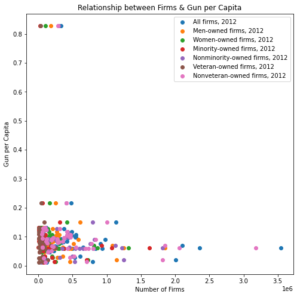

```python
scatterChart('firms')
chartLabel('Number of Firms', 'Gun per Capita', 'Relationship between Firms & Gun per Capita');
```

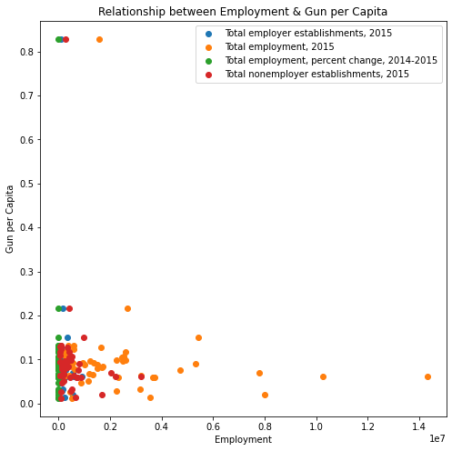

```python
scatterChart('employ')
chartLabel('Employment', 'Gun per Capita', 'Relationship between Employment & Gun per Capita');
```

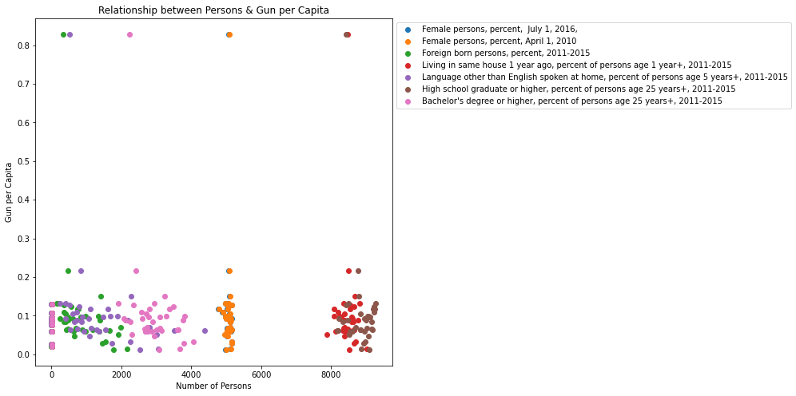

```python
scatterChart('persons')
chartLabel('Number of Persons', 'Gun per Capita', 'Relationship between Persons & Gun per Capita');
```

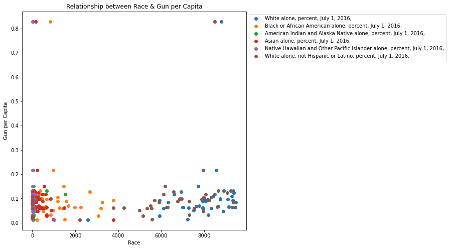

```python
scatterChart('alone')
chartLabel('Race', 'Gun per Capita', 'Relationship between Race & Gun per Capita');
```

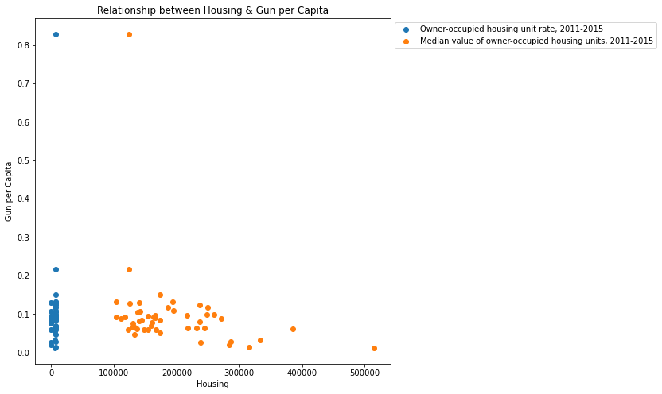

```python
scatterChart('housing')
chartLabel('Housing', 'Gun per Capita', 'Relationship between Housing & Gun per Capita');
```

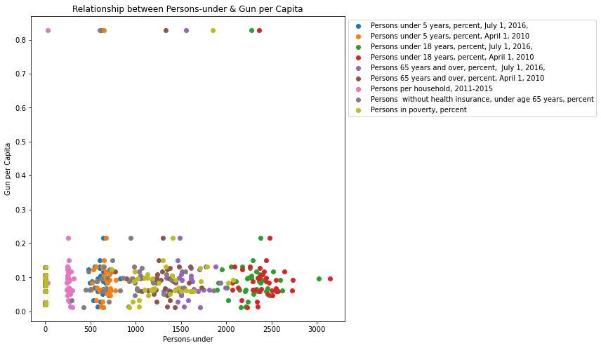

```python
scatterChart('Persons')
chartLabel('Persons-under', 'Gun per Capita', 'Relationship between Persons-under & Gun per Capita');
```

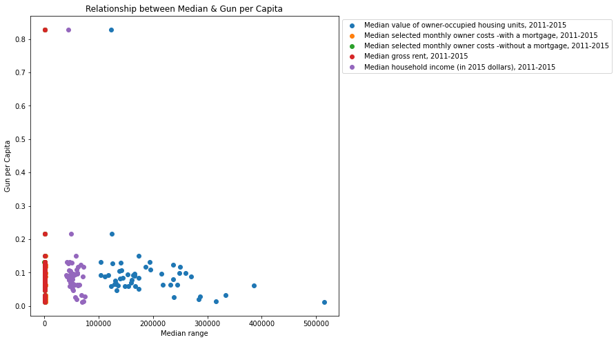

```python
scatterChart('Median')
chartLabel('Median range', 'Gun per Capita', 'Relationship between Median & Gun per Capita');
```

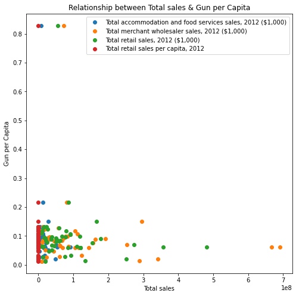

```python
scatterChart('sales')
chartLabel('Total sales', 'Gun per Capita', 'Relationship between Total sales & Gun per Capita');
```

**Summary:** I observed weak correlations between high gun per capita and the following variables: 'Nonveteran-owned firms', 'All firms', 'Total Employment', 'White alone', 'Persons in poverty' and 'Total retail sales'. This relationship should be further explored individually to get a clearer picture.

**Step 4:** Create scatter plots to explore relationship between high gun per capita and census variables showing some level of correlation.

```python
# Create a list with columns that have showed signs of a correlation
newLabels = ['Persons 65 years and over, percent, April 1, 2010',
             'White alone, percent, July 1, 2016,',
             'Asian alone, percent, July 1, 2016,',
             'Foreign born persons, percent, 2011-2015',
             'Total retail sales, 2012 ($1,000)',
             'Persons in poverty, percent',
             'Total employer establishments, 2015',
             'Total employment, 2015',
             'Nonveteran-owned firms, 2012']
```

```python
def newChart(b):
    """
    b = takes a string input of the column name

    """
    plt.figure(figsize = (8, 8))
    plt.scatter(censusDf[b], censusDf['gun_per_capita_16'], label = b)
```

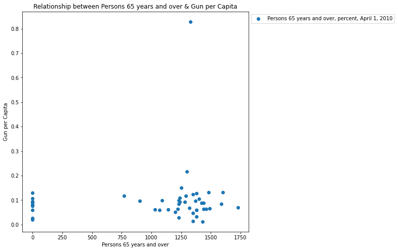

```python
newChart('Persons 65 years and over, percent, April 1, 2010')
chartLabel('Persons 65 years and over', 'Gun per Capita', 'Relationship between Persons 65 years and over & Gun per Capita');
```

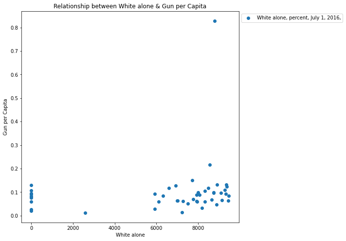

```python
newChart('White alone, percent, July 1, 2016,')
chartLabel('White alone', 'Gun per Capita', 'Relationship between White alone & Gun per Capita');
```

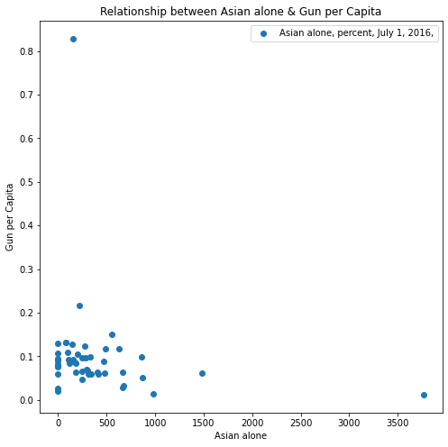

```python
newChart('Asian alone, percent, July 1, 2016,')
chartLabel('Asian alone', 'Gun per Capita', 'Relationship between Asian alone & Gun per Capita');
```

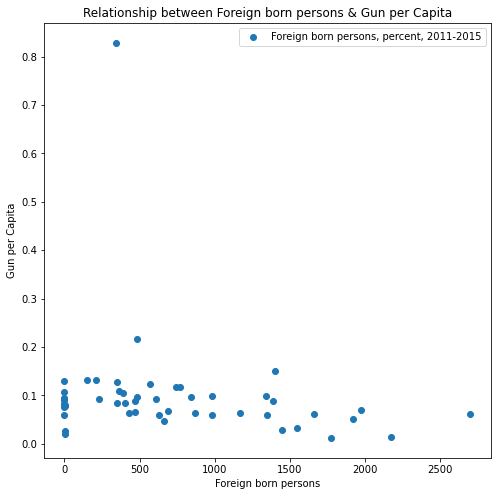

```python
newChart('Foreign born persons, percent, 2011-2015')
chartLabel('Foreign born persons', 'Gun per Capita', 'Relationship between Foreign born persons & Gun per Capita');
```

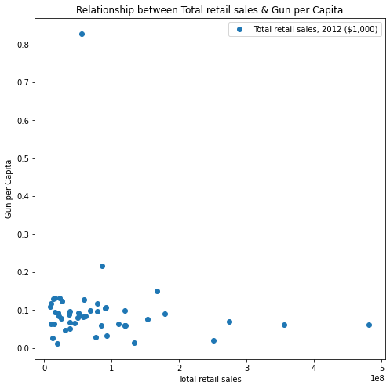

```python
newChart('Total retail sales, 2012 ($1,000)')
chartLabel('Total retail sales', 'Gun per Capita', 'Relationship between Total retail sales & Gun per Capita');
```

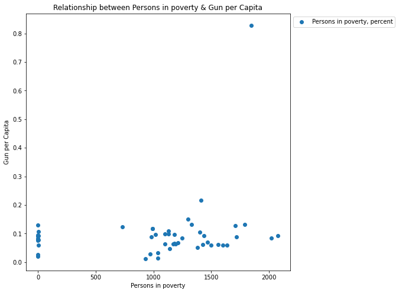

```python
newChart('Persons in poverty, percent')
chartLabel('Persons in poverty', 'Gun per Capita', 'Relationship between Persons in poverty & Gun per Capita');
```

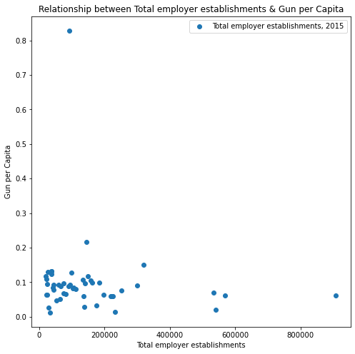

```python
newChart('Total employer establishments, 2015')
chartLabel('Total employer establishments', 'Gun per Capita', 'Relationship between Total employer establishments & Gun per Capita');
```

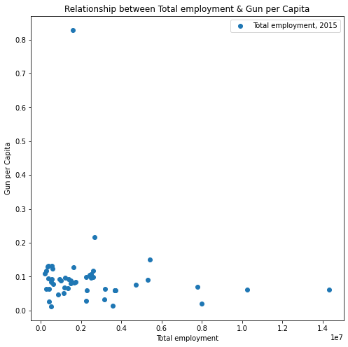

```python
newChart('Total employment, 2015')
chartLabel('Total employment', 'Gun per Capita', 'Relationship between Total employment & Gun per Capita');
```

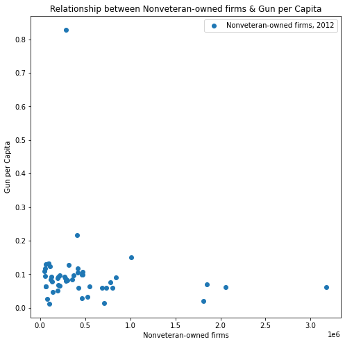

```python
newChart('Nonveteran-owned firms, 2012')
chartLabel('Nonveteran-owned firms', 'Gun per Capita', 'Relationship between Nonveteran-owned firms & Gun per Capita');
```

Also, there was a weak negative correlation with 'Asian alone, percent, July 1, 2016,' and 'Foreign born persons, percent, 2011-2015' census variables.

### What is the overall trend of gun purchases?

To see how gun purchase is trending, we'll create line charts to uncover gun purchase pattern per month and per year. Using a line chart will provide insights into what months of the year have the highest gun purchase, and how gun purchase has grown overtime.

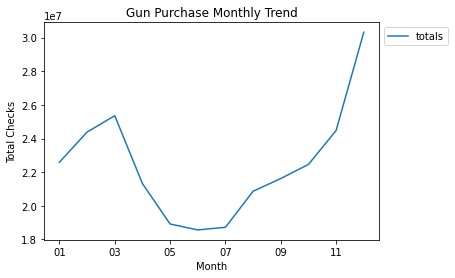

```python
gun_df.groupby('months')['totals'].sum().plot(kind='line')
chartLabel('Month', 'Total Checks', 'Gun Purchase Monthly Trend');
```

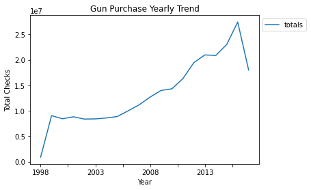

```python
gun_df.groupby('year')['totals'].sum().plot(kind='line')
chartLabel('Year', 'Total Checks', 'Gun Purchase Yearly Trend');
```

**Summary:** From the line chart for month, I deduce that gun purchase varies per month but we'd usually expect to see a peak in gun purchases from December to March.

The line chart for year shows an overall upward trend in gun purchases from 1998 to 2016. The number of gun purchases remained stable aroun 10 million between 1999 to 2005 and grew by over a 150% to above 25 million from 2005 to 2016.

## Conclusions

> I analyzed `gun-data.xlsx` and `u.s. census data.csv` which were both independent datasets but with with common columns like state and year.

> My analysis included cleaning the data and using feature engineering to create new columns and datasets to further blend the datasets and aid proper analysis, and using visualizations to explore the data and present my findings.

### Findings

> There were no strong correlation between census variables and high gun per capita. However, some variable showed weak positive and negative correlation with high gun per capita. To this end, it's difficult to conclude that any census variable is most associated with high gun per capita.

> Finally, gun purchase as an overall upward trend in the last 18 years but with no strong correlation with census variables. Analyzing the relationship between state and high gun per capita might be a more effective option.

### Limitations:

> The FBI gun data contained missing values with I replaced with the mean. However, I dropped the 'Fact Note' column in census data for containing a lot of null values and not being useful for my analysis.

> After merging gun data and census data into one dataset using an inner join, gun data points for states with no match in the census data were dropped to avoid distorting our analysis.

> Gun data contains incomplete data for 2017 hence the decline in gun purchase after 2016.